# Cuantificación del mimetismo vocal heteroespecífico mediante aprendizaje profundo: evidencia en el pájaro campana

**Marcelo Araya-Salas**Universidad de Costa RicaPablo Huertas-VásquezUniversidad Nacional de Costa RicaMarcos Q. OlivaRoyal Holloway University of London

[figure not shown]

[figure not shown]

[figure not shown]

https://marce10.github.io/

## Evolución del aprendizaje vocal

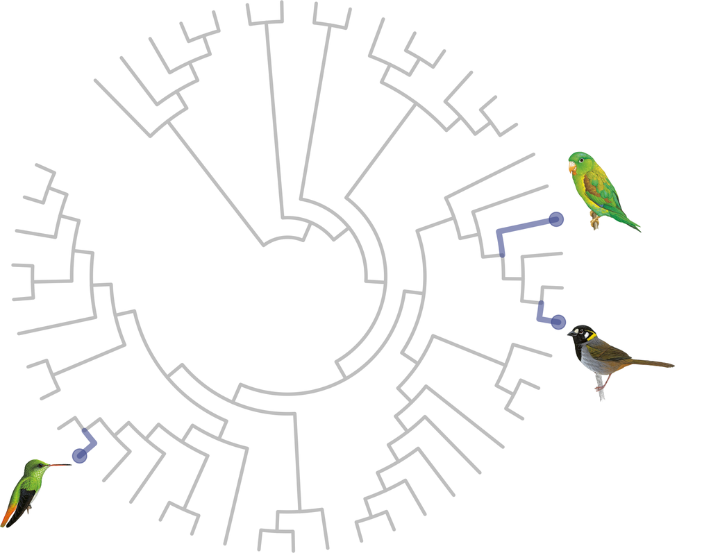

filogenia: Open Tree of Life (McTavish et al. 2025)

## Evolución del aprendizaje vocal

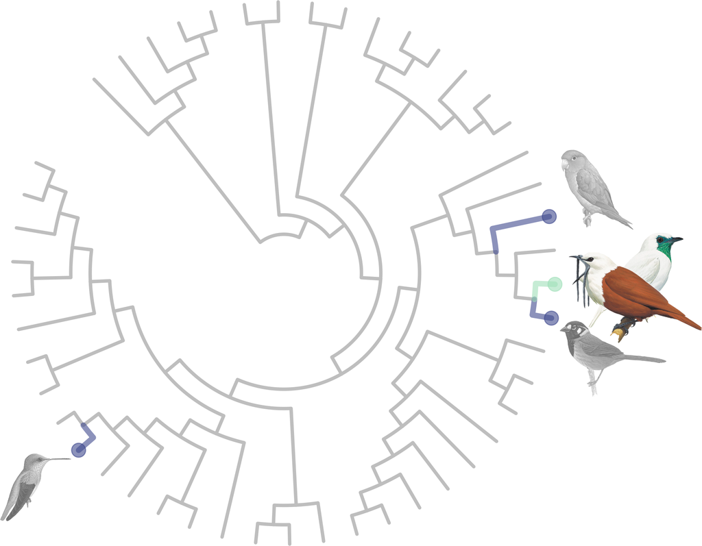

- Género *Procnias*
- Dialectos y evolución cultural en *P. tricarunculatus*
- Aparente imitación en un individuo en cautiverio de *P. nudicollis*

Saranathan et al. 2007; Kroodsma et al. 2013

Adulto de *P. tricarunculatus* en Monteverde, Costa Rica

Campana focal: juvenil de *P. tricarunculatus*, Refugio Bosque Alegre, Costa Rica

## Aparentes imitaciones

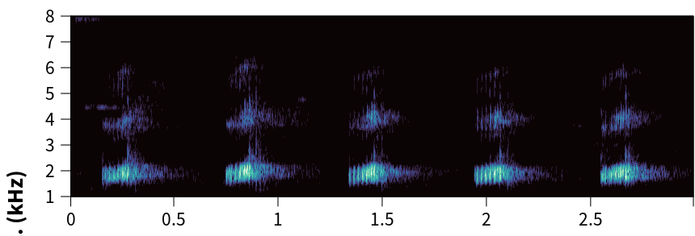

[interactive chart not shown]

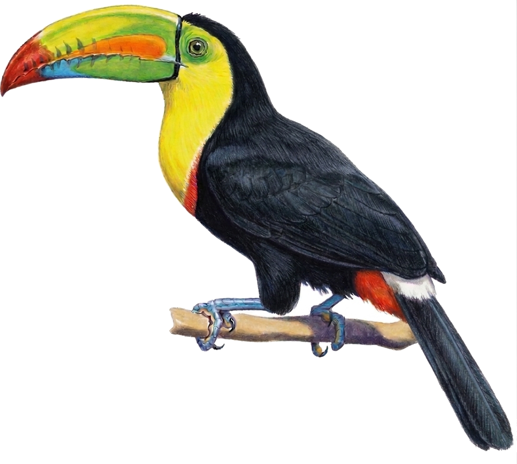

*Ramphastos sulfuratus*

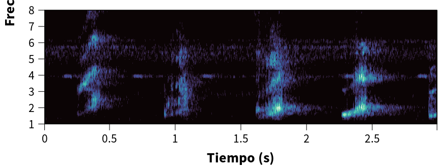

[interactive chart not shown]

Campana focal

## Aparentes imitaciones

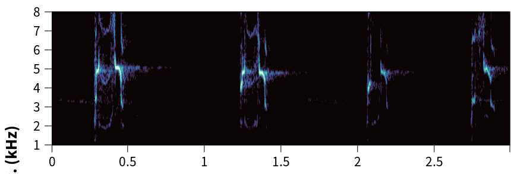

[interactive chart not shown]

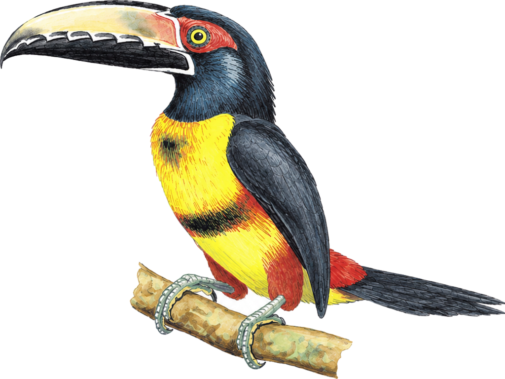

*Pteroglossus torquatus*

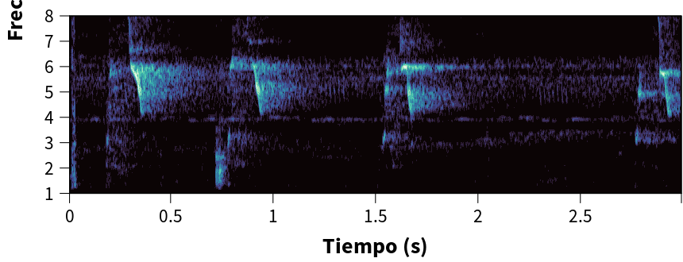

[interactive chart not shown]

Campana focal

## Aparentes imitaciones

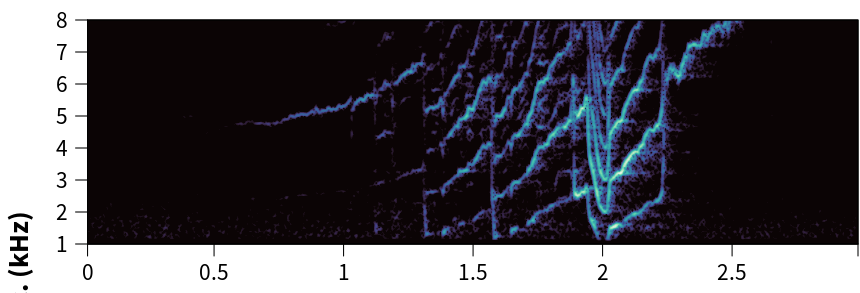

[interactive chart not shown]

[figure not shown]

*Psarocolius montezuma*

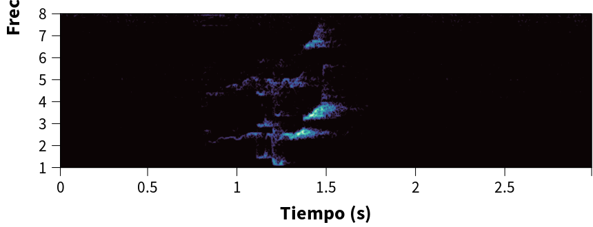

[interactive chart not shown]

Campana focal

## Semejanza vocal

**Mimetismo:** copia de las especies que la campana focal puede escuchar

**Azar:** vocalizaciones variables que solo coinciden por casualidad con otras especies

[figure not shown]

[figure not shown]

SimpátricaAlopátrica

Kelley et al. 2008; Dalziell et al. 2015

## Datos de entrenamiento

Modelo simpátrico

Pariente alopátrico

Pájaro campana

*Ramphastos*tucanes

[figure not shown]

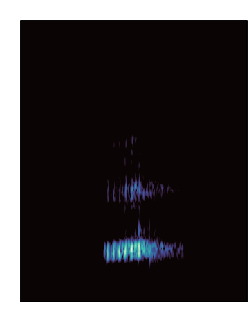

*R. sulfuratus*

[figure not shown]

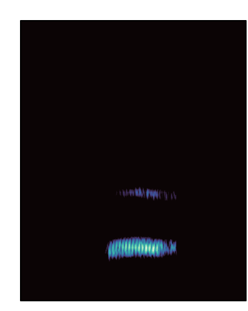

*R. brevis*

[figure not shown]

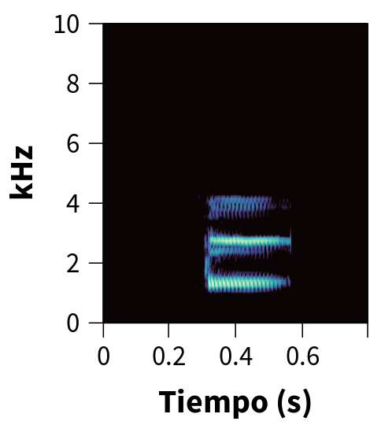

*P. tricarunculatus*

Otros individuos

*Pteroglossus*aracaris

[figure not shown]

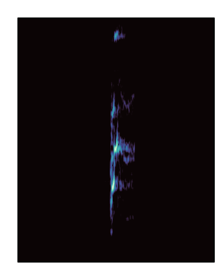

*P. torquatus*

[figure not shown]

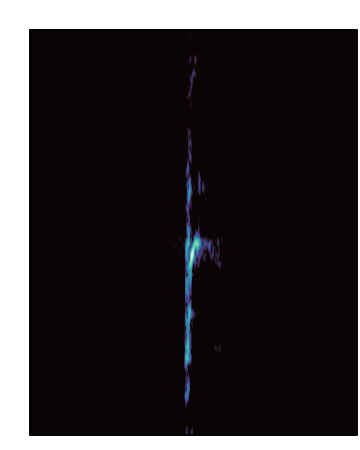

*P. erythropygius*

*Psarocolius*oropéndolas

[figure not shown]

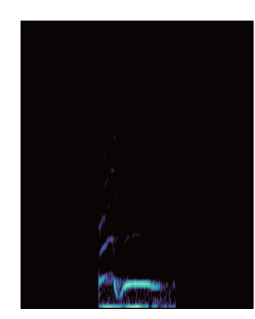

*P. montezuma*

[figure not shown]

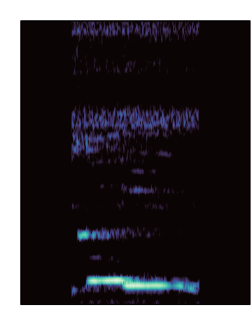

*P. guatimozinus*

Mapas de distribución: BirdLife International 2025